# [STAT 560] Presentation - Abstract

##### Total Number of Records

|  | Products | Customers | Orders |
| --- | --- | --- | --- |
| **Total Number of Records** | 5349 | 22934 | 11482 |

##### Summary of Order data

| Order.ID | Order.Status | Order.Date | Order.Total..inc.tax. | Customer.ID |
| --- | --- | --- | --- | --- |
| Min. :18002 | Shipped :9630 | 08-01-2017: 26 | Min. : 0.00 | Min. : 0 |
| 1st Qu.:23123 | Refunded :1239 | 08-21-2017: 25 | 1st Qu.: 31.94 | 1st Qu.: 96796 |
| Median :27484 | Partially Shipped : 380 | 10-11-2017: 25 | Median : 47.95 | Median : 99362 |
| Mean :27258 | Cancelled : 74 | 12-01-2016: 25 | Mean : 68.62 | Mean : 98868 |
| 3rd Qu.:31636 | Awaiting Fulfillment: 62 | 08-06-2016: 24 | 3rd Qu.: 79.99 | 3rd Qu.:102337 |
| Max. :35766 | Completed : 54 | 09-17-2017: 24 | Max. :2255.26 | Max. :105288 |
| NA | (Other) : 43 | (Other) :11333 | NA | NA |

#### frequency table by state

| state | n |
| --- | --- |
| CA | 301 |
| NY | 250 |
| TX | 243 |
| FL | 238 |
| GA | 149 |
| MD | 149 |
| IL | 127 |
| VA | 122 |
| PA | 116 |
| OH | 112 |
| TN | 108 |
| NC | 107 |
| NJ | 105 |
| LA | 90 |
| MI | 89 |
| AL | 84 |
| SC | 64 |
| MS | 59 |
| MA | 55 |
| MO | 51 |
| IN | 40 |
| AR | 35 |
| WI | 35 |
| NV | 34 |
| MN | 33 |
| WA | 33 |
| AZ | 32 |
| KY | 31 |
| CT | 28 |
| KS | 25 |
| OK | 25 |
| CO | 22 |
| DC | 20 |
| IA | 15 |
| DE | 13 |
| WV | 10 |
| NE | 9 |
| OR | 9 |
| HI | 8 |
| NM | 8 |
| NH | 7 |
| UT | 7 |
| AK | 5 |
| ME | 4 |
| ID | 3 |
| MT | 3 |
| ND | 3 |
| PR | 2 |
| RI | 2 |
| VT | 1 |

```
## [1] "Order.ID"              "Order.Status"          "Order.Date"
## [4] "Order.Time"            "Order.Total..inc.tax." "Customer.ID"
## [7] "Product.Details"       "Transaction.ID"
```

[output not shown]

[output cut: 474 more lines]

```
## 'data.frame':    489 obs. of  8 variables:
##  $ Order.ID             : int  18041 18045 18064 18098 18146 18167 18179 18269 18290 18300 ...
##  $ Order.Status         : Factor w/ 10 levels "Awaiting Fulfillment",..: 9 8 8 10 10 10 10 10 10 10 ...
##  $ Order.Date           : Factor w/ 1381 levels "01-13-2015","01-13-2016",..: 168 172 180 204 115 127 143 312 324 328 ...
##  $ Order.Time           : Factor w/ 11031 levels "0:00:29","0:00:39",..: 8058 1017 6013 7452 2699 7121 5839 3703 2627 1732 ...
##  $ Order.Total..inc.tax.: num  105 238 79 62 134 ...
##  $ Customer.ID          : int  94666 82493 93355 95198 81683 95226 95236 95282 95296 89114 ...
##  $ Product.Details      : chr  "9519" "10117" "9439|9443|10307|10465" "10232|10443" ...
##  $ Transaction.ID       : Factor w/ 11960 levels "","00035057VE553154W",..: 11702 11693 11730 11767 11807 11833 11846 5683 11521 11529 ...
```

```
## # A tibble: 367 x 2
## # Groups:   prdID [367]
##     prdID     n
##    <fctr> <int>
##  1  11986    24
##  2  10613    18
##  3  10668    16
##  4  10785    15
##  5  11980    14
##  6  10786    12
##  7  10725     9
##  8  10629     8
##  9  10676     8
## 10  14825     8
## # ... with 357 more rows
```

At CA state 11986, 10613, 10668, 10785, 11980, 10786, 10725, 10629, 10676, 14825 products are popular

| Hollywood |
| --- |
| Bobbi Boss |
| Beverly Johnson |
| Aplus |
| Aplus |
| Aplus |
| Clairol Professional |
| Adore |

Those brands are the most popular in CA

#### Draw time series plot by orderID

### Frequency of number of sales

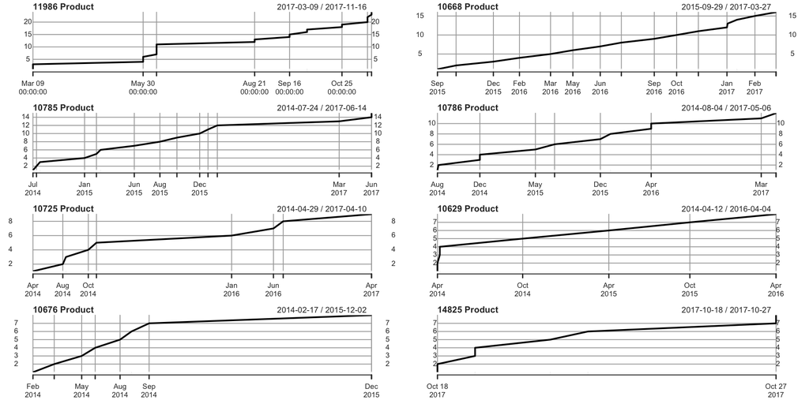

Assume

All most of all visitor is comes from google ads. It means the sales rate shows the current trend of wig style.

If we can read a trend of current style we may can list more relative product under their first product also we can conduct email marketing